# Web Scrapping (ECON/POLISCI 151, Week 2 Section)

## General Websites

We will use a CNN page on the war in Ukraine as an example. First, we need to use the `read_html` function to read the html document. In the previous section, we passed it a string with html syntax. We can also pass it a url.

```r
# read the documentation to see what we can pass the function
# ?xml2::read_html  # read_html is actually from xml2, which rvest imports

cnn_url <- "https://www.cnn.com/europe/live-news/ukraine-russia-putin-news-04-3-22/h_4d0118cfd6f30770be0f8f54e041f9d2"
cnn_page <- cnn_url %>% rvest::read_html()
```

There are many types of data you might want from a webpage, and each will require a different method of extraction. In this case, we’re looking at an article and most likely will want the contents of that article. As a starting point, we might want to look at text that is sandwiched by p tags:

```r
cnn_text <- cnn_page %>%
  rvest::html_elements("p") %>%  # elements delimited by the p tag
  rvest::html_text()  # text inside the tag
head(cnn_text)
```

```
## [1] "By Simone McCarthy, Steve George, Sana Noor Haq, Melissa Macaya, Mike Hayes, Maureen Chowdhury and Amir Vera, CNN"
## [2] "From CNN's Jonny Hallam "
## [3] ""
## [4] "The bodies of at least 20 civilian men have been found lying strewn across the street in the town of Bucha, northwest of Kyiv following the withdrawal of Russian forces from the area in shocking images released by AFP on Saturday. "
## [5] "The dead, all in civilian clothing, are found in a variety of awkward poses, some face down against the pavement, others facing upwards with mouths open.  "
## [6] "\"Three of them are tangled up in bicycles after taking their final ride, while others, with waxy skin, have fallen next to bullet-ridden and crushed cars,\" according to AFP journalists who accessed the town after it had been cut off for nearly a month."
```

This gives us a vector of all the text in each of the paragraph elements on the webpage.

(Alternatively, you can look try other tags, like “body” – just note that using a different tag will also mean the output is formated differently (and all the paragraphs will be smooshed together).)

Another example is images: Perhaps we are interested in seeing what types of images news organizations with different political leanings tend to use when covering a given subject (e.g., are more right-leaning news organizations more likely to include pictures of violence/destruction of property when reporting on BLM?). To do this, we will retrieve the `src` attribute of the `img` element.

```r
cnn_img <- cnn_page %>%
  rvest::html_elements("img") %>%  # img elements
  rvest::html_attr("src")  # the src attribute
```

This gives us links to the images, which we can then feed to whatever learner (or human coder) we want. Maybe we also want to store the captions for these photos:

```r
cnn_cap <- cnn_page %>% rvest::html_elements("figcaption") %>% rvest::html_text()
cnn_img_df <- cbind(link_to_img = cnn_img, caption = cnn_cap)
cnn_img_df[1:2, ]  # first two examples
```

```
##      link_to_img
## [1,] "https://dynaimage.cdn.cnn.com/cnn/digital-images/org/a34e1e33-dff8-478a-ac2e-7d523421b67f.jpeg"
## [2,] "https://dynaimage.cdn.cnn.com/cnn/digital-images/org/c793ffa3-2eba-4dc9-ac37-304305383611.jpeg"
##      caption
## [1,] "A man walks with bags of food given to him by the Ukrainian Army in Bucha, Ukraine on April 2. (Ronaldo Schemidt/AFP/Getty Images)"
## [2,] "David Arakhamia, left, Mykhailo Podolyak, center and Crimean Tatar leader Mustafa Dzhemilev speak with the media after their meeting with Russian negotiators in Istanbul, Turkey on March 29.  (Mehmet Emin Caliskan/Reuters)"
```

What you do with this information is a whole ’nother story. We will learn a bit about how to use text as data in a future section, but computer vision is beyond the scope of this class.

There is, however, one concern that we can address now: What if we can’t/don’t want to collect the url of potentially thousands of websites? In some circumstances, there will be websites that aggregate other websites, and we can scrape urls from such aggregators. In this case, we can use Google News, which aggregates links to news articles.

## Aggregation Websites: e.g., Google News

This section will walk you through the process of scraping Google News for articles on a specific topic. We will use “ukraine” as the example, but this code can be readily repurposed for search term(s). This is because Google News uses a fixed url format that varies only in the search term, which makes it easy for us to write flexible code. To see what this url is, you can just go to the Google News page and search for something. The url will have a field beggining with `q` (for query), followed by whatever you search for. (This doesn’t just have to be a set of words; you can look up Google url search parameters to see how else you can narrow your search. For the purposes of this demonstration, though, let’s keep it simple.)

```r
## Get the search result page
term <- "ukraine"
url <- paste0("https://news.google.com/search?q=", term,
              "&hl=en-US&gl=US&ceid=US%3Aen")
html_doc <- rvest::read_html(url)
```

We want to get the html node that links to the article. Fortunately for us, Google defines a specific class for such elements. To see what it’s called, we can open Google News and use Chrome’s inspection tool under `View > Developer > Inspect Elements` tool and mouse over the link.

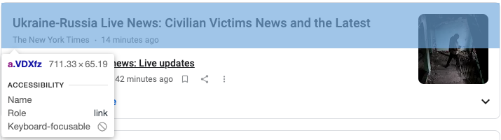

The class we want is called “VDXfz” (the CSS selector for class is `.class`), and we want to extract the hyperlink from it, which is specified using the `href` attribute.

```r
## Get links on the page
links <- html_doc %>% rvest::html_nodes('.VDXfz') %>%  # specify CSS selector: .class
  rvest::html_attr('href')
```

If we take a look at the html code for the webpage, we can see that the link is a relative path (a path that begins with the current directory, e.g., “./index.html”).

[figure not shown]

But we want an absolute path (the link you can enter into a web browser, e.g., “https://nytimes.com”). To get it in this format, we need to replace the root.

```r
# this will give us links in the following format:
links[1]
```

```
## [1] "./articles/CAIiEI7VrCNdzk4qGBPa-cONofUqFwgEKg4IACoGCAow9vBNMK3UCDCmvJYH?hl=en-US&gl=US&ceid=US%3Aen"
```

```r
# we want them instead to begin with the Google News address
links <- gsub("./articles/", "https://news.google.com/articles/", links)
```

Let’s also record the title of each article. To see how to get this info, let’s go back to Google News and open Chromes’ Devloper Tools UI (or open the raw html file) and look for the corresponding node:

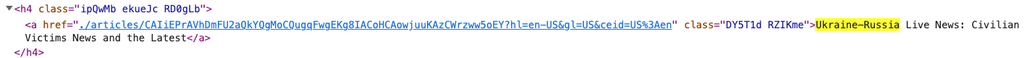

Titles seem to be assigned the “DY5T1d” class attribute (it’s actually a part of two classes; we use take either). We want to extract the text from this element.

```r
titles <- html_doc %>% rvest::html_nodes('.DY5T1d') %>%
  rvest::html_text()

# same thing if we use the other class
# html_doc %>%  rvest::html_nodes('.RZIKme') %>% rvest::html_text()

# take the first five words
trunc <- sapply(titles, FUN=function(x)
  paste(c(unlist(strsplit(x, split=" +"))[1:5], "..."), collapse=" "))
df <- cbind(title = titles, truncated_title = unname(trunc), link = links)
head(df[, c(2:3)])
```

```
##      truncated_title
## [1,] "Russia-Ukraine war: What happened today ..."
## [2,] "Russia-Ukraine live updates: Russia has ..."
## [3,] "April 7, 2022 Russia-Ukraine news ..."
## [4,] "Russia-Ukraine war: what we know ..."
## [5,] "Russia-Ukraine war live: European Union ..."
## [6,] "Latest Russia-Ukraine war news: Live ..."
##      link
## [1,] "https://news.google.com/articles/CAIiEI7VrCNdzk4qGBPa-cONofUqFwgEKg4IACoGCAow9vBNMK3UCDCmvJYH?hl=en-US&gl=US&ceid=US%3Aen"
## [2,] "https://news.google.com/articles/CBMiTWh0dHBzOi8vYWJjbmV3cy5nby5jb20vSW50ZXJuYXR…?hl=en-US&gl=US&ceid=US%3Aen"
## [3,] "https://news.google.com/articles/CBMiUmh0dHBzOi8vd3d3LmNubi5jb20vZXVyb3BlL2xpdmU…?hl=en-US&gl=US&ceid=US%3Aen"
## [4,] "https://news.google.com/articles/CAIiEFVpBC94zEwG22YFHw041XEqFwgEKg4IACoGCAowl6p7MN-zCTDZ4PsF?hl=en-US&gl=US&ceid=US%3Aen"
## [5,] "https://news.google.com/articles/CAIiEJjnWHse6KDeIoVlWbYV8KAqFggEKg4IACoGCAow3vI9MPeaCDDciw4?hl=en-US&gl=US&ceid=US%3Aen"
## [6,] "https://news.google.com/articles/CAIiEPDaV1_xn0kEorlvIt0JsDQqGAgEKg8IACoHCAowjtSUCjC30XQwpo69Bg?hl=en-US&gl=US&ceid=US%3Aen"
```

Now that we have the links to all these web pages, we can just loop through and do what we did in the first section to extract all the text/images (or whatever information you want).

## APIs: e.g., Twitter

What we did in the previous section is a bit cumbersom and the results messy. For example, though our intention was only to gather the body of the article, our data also includes author names.

Sometimes, it’s much easier. Some websites have application programming interfaces (APIs), which you can query for specific and well-structured information. Twitter is one such website.

This time let’s use a timely but lighter subject as an example: the Oscars.

To access Twitter’s API, you need to [register as a devloper](https://developer.twitter.com/).

We’ll use the `rtweet` package. The `search_tweets()` function allows you to search for tweets, and you can specify a number of parameters or filters. We can be quite specific with what types of tweets we want to query. The “q” argument uses the syntax of Twitter’s [search operators](https://developer.twitter.com/en/docs/twitter-api/v1/rules-and-filtering/search-operators).

```r
# tweets that: mention the oscars & are from verified users & are not replies
tw <- rtweet::search_tweets(q="\"oscars\" filter:verified -filter:replies",
                            include_rts = F,  # exclude retweets
                            lang="en",  # only tweets in English
                            n=10)  # 10 tweets
```

The information is also organized nicely:

```r
# what type of information do we have
head(colnames(tw))
```

```
## [1] "user_id"     "status_id"   "created_at"  "screen_name" "text"
## [6] "source"
```

```r
# example of the text in a tweet
tw$text[1]
```

```
## [1] "The academy said Smith's behavior was “unacceptable and harmful.” https://t.co/OHOR2ksTfS"
```

This is already looking cleaner than our news article example, but let’s still do a bit of pre-processing. We’ll go more in depth during our week on text as data, but for now let’s just define a basic function for removing some (typically) unmeaningful words, as well as punctuation and whitespace, and apply it to each tweet.

```r
clean_text <- function(x) {
  x %>% tm::removeWords(stopwords::stopwords("en")) %>%
    tm::stripWhitespace() %>%
    tm::removePunctuation()
}

## Clean tweets
# before
tw[, c("screen_name", "text")]
```

```
## # A tibble: 10 × 2
##    screen_name   text
##    <chr>         <chr>
##  1 toledonews    "The academy said Smith's behavior was “unacceptable and harmf…
##  2 ETCanada      ".@TheAcademy has banned #WillSmith from attending the #Oscars…
##  3 GBNEWS        "'How comfortable must he have felt to have got up in the midd…
##  4 sunriseon7    "Will Smith has been banned from the Oscars for 10 years after…
##  5 MikeGwizdala  "The planet is on fire but yes, do go on about Will Smith bein…
##  6 MarketWatch   "Was the academy's decision to ban Will Smith from attending t…
##  7 77WABCradio   "https://t.co/NqA1Ayj4ki\n\nActor Will Smith banned from the O…
##  8 RebeccaOnFOX7 "Oscars slap scandal: The Academy announces Will Smith's punis…
##  9 live955       "Will Smith Gets 10-Year Ban From Oscars https://t.co/TjnxG2kv…
## 10 RobGuaderrama "Will Smith banned from the #Oscars for a decade. Details: htt…
```

```r
# after
tw_wrds <- unname(sapply(tw$text, clean_text))
head(tw_wrds)
```

```
## [1] "The academy said Smiths behavior “unacceptable harmful” httpstcoOHOR2ksTfS"
## [2] "TheAcademy banned WillSmith attending Oscars 10 years httpstcocLMshtTqO5"
## [3] "How comfortable must felt got middle speech just slap Chris Rock The Headliners react news Will Smith banned The Oscars ten years following slap Chris Rock 🖥 GB News YouTube httpstcoWa58gYGZwF httpstcoBFmztNGe0M"
## [4] "Will Smith banned Oscars 10 years slapped Chris Rock last months Academy Awards httpstcoaqferYf2Id"
## [5] "The planet fire yes go Will Smith banned Oscars umpteenth time SMH"
## [6] "Was academys decision ban Will Smith attending Oscars 10 years fair punishment hitting Chris Rock httpstcoZ1UJdwOkcS"
```

Again, what you do with this data is a different topic. For now, let’s do something simple: see which words appear the most often.

```r
# split into words
tw_wrds <- sapply(tw_wrds, FUN=function(x) strsplit(tolower(x), split=" +"))

count <- table(unlist(tw_wrds))
sort(count[count > 1], decreasing = T)
```

```
##
##     oscars       will      smith     banned        the      years         10
##          9          8          7          6          5          5          4
##      chris       rock    academy       slap  attending        ban       news
##          4          4          3          3          2          2          2
## punishment     smiths  willsmith
##          2          2          2
```

The `rtweet` package has lots of other functions that you may find useful. If you want to use Twitter for your project, I encourage you to read the package’s documentation. I’ll just point out one other function, one which gets tweets from a specific user:

```r
# last 2 tweets from the UN
tl <- rtweet::get_timeline(user="UN", n=2)
tl$text
```

```
## [1] "The UN is helping people affected by the war in Ukraine by providing:\n\n🔹 protection &amp; shelter for refugees\n🔹 support for children &amp; families\n🔹 food &amp; water\n🔹 healthcare &amp; much more. \n\nhttps://t.co/eX16SnexeC https://t.co/PndCHZpvGe"
## [2] "🇸🇾#Syria: The victims and their families deserve to know the fate and whereabouts of their missing relatives, says UN Human Rights Chief @mbachelet.\n\nWe need to act NOW.\n\n👉https://t.co/7edfB8nRHy https://t.co/73Z2ifRWNw"
```

Lastly, we can do all this without the `rtweet` package, though it takes considerably more effort. Take a look at the supplement if interested; the supplement is also a nice jumping off point if you want to make requests to other APIs, some of which may not have R packages to do the leg work for you.